# Sham_Solanki_Customer_Churn_Notebook

## 1. Data Overview

```python
from google.colab import drive
drive.mount('/content/drive')

# Define the file path (assuming 'listings_summary.csv' is in the root of 'My Drive')
path = '/content/drive/MyDrive/GL DSBA/Capstone Project/Interim Project/customer_churn.csv'
```

```python
# Core
import numpy as np
import pandas as pd

# Visualization
import matplotlib.pyplot as plt
import seaborn as sns

# Preprocessing
from sklearn.model_selection import train_test_split
from sklearn.preprocessing import StandardScaler
from sklearn.compose import ColumnTransformer
from sklearn.pipeline import Pipeline
from sklearn.impute import SimpleImputer

# Models
from sklearn.linear_model import LogisticRegression
from sklearn.tree import DecisionTreeClassifier
from sklearn.ensemble import RandomForestClassifier, GradientBoostingClassifier, AdaBoostClassifier, BaggingClassifier

# Metrics
from sklearn.metrics import (
    accuracy_score, precision_score, recall_score, f1_score,
    roc_auc_score, average_precision_score, confusion_matrix, classification_report
)

# Tuning
from sklearn.model_selection import GridSearchCV, RandomizedSearchCV

# Handling imbalance
from imblearn.over_sampling import SMOTE
from imblearn.pipeline import Pipeline as ImbPipeline
```

```python
import numpy as np
import pandas as pd
import matplotlib.pyplot as plt
import seaborn as sns

sns.set(style="whitegrid")

data = pd.read_csv(path)
```

```python
data.shape
```

```
(12055, 20)
```

```python
data.info()
```

```
<class 'pandas.core.frame.DataFrame'>
RangeIndex: 12055 entries, 0 to 12054
Data columns (total 20 columns):
 #   Column            Non-Null Count  Dtype
---  ------            --------------  -----
 0   gender            12055 non-null  object
 1   SeniorCitizen     12055 non-null  int64
 2   Partner           12055 non-null  object
 3   Dependents        12055 non-null  object
 4   tenure            11451 non-null  float64
 5   PhoneService      12055 non-null  object
 6   MultipleLines     12055 non-null  object
 7   InternetService   12055 non-null  object
 8   OnlineSecurity    12055 non-null  object
 9   OnlineBackup      12055 non-null  object
 10  DeviceProtection  12055 non-null  object
 11  TechSupport       12055 non-null  object
 12  StreamingTV       12055 non-null  object
 13  StreamingMovies   12055 non-null  object
 14  Contract          12055 non-null  object
 15  PaperlessBilling  12055 non-null  object
 16  PaymentMethod     12055 non-null  object
 17  MonthlyCharges    12055 non-null  object
 18  TotalCharges      12055 non-null  object
 19  Churn             12055 non-null  object
dtypes: float64(1), int64(1), object(18)
memory usage: 1.8+ MB
```

## 2. Data Quality Issues and Preprocessing

### 2.1 Invalid and Anomalous Values

```python
data['tenure'].unique()
```

[output not shown]

```python
data.loc[data['tenure'] < 0, 'tenure'] = np.nan
```

### 2.2 Cleaning Numeric Columns

```python
#Clean MonthlyCharges
data['MonthlyCharges'] = data['MonthlyCharges'].astype(str).str.replace(r'[^0-9.]', '', regex=True)
data['MonthlyCharges'] = data['MonthlyCharges'].replace('', np.nan)
data['MonthlyCharges'] = data['MonthlyCharges'].astype(float)

#2. Clean TotalCharges
data['TotalCharges'] = data['TotalCharges'].astype(str).str.replace(r'[^0-9.]', '', regex=True)
data['TotalCharges'] = data['TotalCharges'].replace('', np.nan)
data['TotalCharges'] = data['TotalCharges'].astype(float)
```

### 2.3 Missing Value Analysis

```python
data.isna().sum()
```

|  | 0 |
| --- | --- |
| gender | 0 |
| SeniorCitizen | 0 |
| Partner | 0 |
| Dependents | 0 |
| tenure | 731 |
| PhoneService | 0 |
| MultipleLines | 0 |
| InternetService | 0 |
| OnlineSecurity | 0 |
| OnlineBackup | 0 |
| DeviceProtection | 0 |
| TechSupport | 0 |
| StreamingTV | 0 |
| StreamingMovies | 0 |
| Contract | 0 |
| PaperlessBilling | 0 |
| PaymentMethod | 0 |
| MonthlyCharges | 301 |
| TotalCharges | 1205 |
| Churn | 0 |

**dtype:** int64

#### Tenure

Tenure is a critical predictor of churn. Since imputing tenure could introduce bias and harm model performance, rows with missing tenure values were removed.

```python
data = data.dropna(subset=['tenure'])
```

#### MonthlyCharges

```python
data['MonthlyCharges'].isna().sum()
```

```
np.int64(287)
```

MonthlyCharges is determined primarily by service configuration, including internet type, contract length, and value-added services. Customers with similar service profiles are expected to have comparable monthly charges. So we will impute monthly charges based on similar customer profiles.

```python
group_cols = [
    'InternetService',
    'Contract',
    'OnlineSecurity',
    'TechSupport',
    'StreamingTV',
    'StreamingMovies',
    'PhoneService'
]

monthly_charge_median = (
    data
    .groupby(group_cols)['MonthlyCharges']
    .median()
)

def impute_monthly_charges(row):
    if pd.isna(row['MonthlyCharges']):
        try:
            return monthly_charge_median.loc[
                tuple(row[col] for col in group_cols)
            ]
        except KeyError:
            return np.nan
    return row['MonthlyCharges']

data['MonthlyCharges'] = data.apply(impute_monthly_charges, axis=1)
```

```python
data['MonthlyCharges'].isna().sum()
```

```
np.int64(0)
```

#### TotalCharges

Due to real-world billing complexities such as prorated charges and one-time fees, TotalCharges was not imputed or back-calculated. It was retained for EDA but excluded from predictive modeling to prevent noise, multicollinearity, and data leakage.

```python
data['TotalCharges'].isna().sum()
```

```
np.int64(1128)
```

Methodology: Missing Value Treatment

- Invalid tenure values were treated as missing and removed due to high business importance.
- MonthlyCharges was imputed using median values of customers with similar service profiles.
- TotalCharges was retained only for EDA analysis(if necessary) but will be excluded from modeling to prevent leakage and multicollinearity

### 2.4 Outlier Handling

```python
# We apply outlier treatment only on continuous monetary and tenure variables
outlier_cols = ['tenure', 'MonthlyCharges']

for col in outlier_cols:
    Q1 = data[col].quantile(0.25)
    Q3 = data[col].quantile(0.75)
    IQR = Q3 - Q1

    lower_bound = Q1 - 1.5 * IQR
    upper_bound = Q3 + 1.5 * IQR

    # Count outliers before treatment
    outliers_before = ((data[col] < lower_bound) | (data[col] > upper_bound)).sum()

    # Winsorization: cap instead of delete
    data[col] = np.where(data[col] < lower_bound, lower_bound, data[col])
    data[col] = np.where(data[col] > upper_bound, upper_bound, data[col])

    outliers_after = ((data[col] < lower_bound) | (data[col] > upper_bound)).sum()

    print(f"{col}: Outliers before = {outliers_before}, after = {outliers_after}")
```

```
tenure: Outliers before = 0, after = 0
MonthlyCharges: Outliers before = 0, after = 0
```

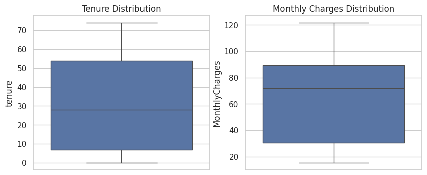

```python
fig, ax = plt.subplots(1, 2, figsize=(10,4))
sns.boxplot(y=data['tenure'], ax=ax[0])
ax[0].set_title("Tenure Distribution")

sns.boxplot(y=data['MonthlyCharges'], ax=ax[1])
ax[1].set_title("Monthly Charges Distribution")
plt.show()
```

the data is well behaved with respect to outliers, this is a positive validation on the quality of the dataset.

### 2.5 Data Type Conversion

#### converting columns to bool

```python
def yes_no_to_bool(series):
    return series.str.strip().str.lower().map({'yes': True, 'no': False}).astype('bool')

# Apply to all Yes/No binary columns
binary_cols = ['Partner', 'Dependents', 'PhoneService', 'PaperlessBilling', 'Churn']
for col in binary_cols:
    data[col] = yes_no_to_bool(data[col])
```

```python
# Convert SeniorCitizen column (0/1) to boolean
data['SeniorCitizen'] = data['SeniorCitizen'].map({0: False, 1: True})
```

#### Converting columns to categorical

```python
categorical_cols = [
    'gender', 'MultipleLines', 'InternetService', 'OnlineSecurity',
    'OnlineBackup', 'DeviceProtection', 'TechSupport', 'StreamingTV',
    'StreamingMovies', 'Contract', 'PaymentMethod'
]

for col in categorical_cols:
    data[col] = data[col].astype('category')


for col in categorical_cols:
    print(f"{col}: {data[col].unique()}")
```

```
gender: ['Female', 'Male']
Categories (2, object): ['Female', 'Male']
MultipleLines: ['No phone service', 'No', 'Yes']
Categories (3, object): ['No', 'No phone service', 'Yes']
InternetService: ['DSL', 'Fiber optic', 'No']
Categories (3, object): ['DSL', 'Fiber optic', 'No']
OnlineSecurity: ['No', 'Yes', 'No internet service']
Categories (3, object): ['No', 'No internet service', 'Yes']
OnlineBackup: ['Yes', 'No', 'No internet service']
Categories (3, object): ['No', 'No internet service', 'Yes']
DeviceProtection: ['No', 'Yes', 'No internet service']
Categories (3, object): ['No', 'No internet service', 'Yes']
TechSupport: ['No', 'Yes', 'No internet service']
Categories (3, object): ['No', 'No internet service', 'Yes']
StreamingTV: ['No', 'Yes', 'No internet service']
Categories (3, object): ['No', 'No internet service', 'Yes']
StreamingMovies: ['No', 'Yes', 'No internet service']
Categories (3, object): ['No', 'No internet service', 'Yes']
Contract: ['Month-to-month', 'One year', 'Two year']
Categories (3, object): ['Month-to-month', 'One year', 'Two year']
PaymentMethod: ['Electronic check', 'Mailed Check', 'Mailed check', 'bank transfer (automatic)', 'ELECTRONIC CHECK', ..., '  Mailed check  ', '  Bank transfer (automatic)  ', 'Credit Card (Automatic)', 'electronic check', 'mailed check']
Length: 20
Categories (20, object): ['  Bank transfer (automatic)  ', '  Credit card (automatic)  ', '  Electronic check  ',
                          '  Mailed check  ', ..., 'bank transfer (automatic)',
                          'credit card (automatic)', 'electronic check', 'mailed check']
```

Redundant categories are being created due to upper/lower case differences for the same words. Lets make all categorical type columns have lower case strings.

```python
for col in categorical_cols:
    data[col] = data[col].str.strip().str.lower()
```

```python
categorical_cols = [
    'gender', 'MultipleLines', 'InternetService', 'OnlineSecurity',
    'OnlineBackup', 'DeviceProtection', 'TechSupport', 'StreamingTV',
    'StreamingMovies', 'Contract', 'PaymentMethod'
]

for col in categorical_cols:
    data[col] = data[col].astype('category')


for col in categorical_cols:
    print(f"{col}: {data[col].unique()}")
```

```
gender: ['female', 'male']
Categories (2, object): ['female', 'male']
MultipleLines: ['no phone service', 'no', 'yes']
Categories (3, object): ['no', 'no phone service', 'yes']
InternetService: ['dsl', 'fiber optic', 'no']
Categories (3, object): ['dsl', 'fiber optic', 'no']
OnlineSecurity: ['no', 'yes', 'no internet service']
Categories (3, object): ['no', 'no internet service', 'yes']
OnlineBackup: ['yes', 'no', 'no internet service']
Categories (3, object): ['no', 'no internet service', 'yes']
DeviceProtection: ['no', 'yes', 'no internet service']
Categories (3, object): ['no', 'no internet service', 'yes']
TechSupport: ['no', 'yes', 'no internet service']
Categories (3, object): ['no', 'no internet service', 'yes']
StreamingTV: ['no', 'yes', 'no internet service']
Categories (3, object): ['no', 'no internet service', 'yes']
StreamingMovies: ['no', 'yes', 'no internet service']
Categories (3, object): ['no', 'no internet service', 'yes']
Contract: ['month-to-month', 'one year', 'two year']
Categories (3, object): ['month-to-month', 'one year', 'two year']
PaymentMethod: ['electronic check', 'mailed check', 'bank transfer (automatic)', 'credit card (automatic)']
Categories (4, object): ['bank transfer (automatic)', 'credit card (automatic)', 'electronic check',
                         'mailed check']
```

```python
data.info()
```

```
<class 'pandas.core.frame.DataFrame'>
Index: 11324 entries, 0 to 12053
Data columns (total 20 columns):
 #   Column            Non-Null Count  Dtype
---  ------            --------------  -----
 0   gender            11324 non-null  category
 1   SeniorCitizen     11324 non-null  bool
 2   Partner           11324 non-null  bool
 3   Dependents        11324 non-null  bool
 4   tenure            11324 non-null  float64
 5   PhoneService      11324 non-null  bool
 6   MultipleLines     11324 non-null  category
 7   InternetService   11324 non-null  category
 8   OnlineSecurity    11324 non-null  category
 9   OnlineBackup      11324 non-null  category
 10  DeviceProtection  11324 non-null  category
 11  TechSupport       11324 non-null  category
 12  StreamingTV       11324 non-null  category
 13  StreamingMovies   11324 non-null  category
 14  Contract          11324 non-null  category
 15  PaperlessBilling  11324 non-null  bool
 16  PaymentMethod     11324 non-null  category
 17  MonthlyCharges    11324 non-null  float64
 18  TotalCharges      10196 non-null  float64
 19  Churn             11324 non-null  bool
dtypes: bool(6), category(11), float64(3)
memory usage: 543.4 KB
```

### 2.6 Duplicate Check

```python
data.duplicated().sum()
```

```
np.int64(24)
```

```python
data = data.drop_duplicates()
```

```python
data.shape
```

```
(11300, 20)
```

### 2.7 Class Imbalance

```python
data['Churn'].value_counts(normalize=True)
```

| Churn | proportion |
| --- | --- |
| False | 0.721327 |
| True | 0.278673 |

**dtype:** float64

Churn distribution shows moderate class imbalance. Given the imbalance is inline with what a real world situation looks like, no resampling techniques were applied at the baseline stage. Instead we will use AUC-PR as our primary metric to measure model performance so that a correct classification of a churn risk customers(Churn = True) is prioritised. Recall/ROC-AUC will be additional metrics to be considered.

## 3. Exploratory Data Analysis

helper function

```python
def add_bar_labels(ax, fmt="{:.2f}"):
    for p in ax.patches:
        height = p.get_height()
        if not np.isnan(height):
            ax.annotate(fmt.format(height),
                        (p.get_x() + p.get_width() / 2., height),
                        ha='center', va='bottom',
                        fontsize=9, xytext=(0, 3),
                        textcoords='offset points')
```

### 3.1 Churn Distribution

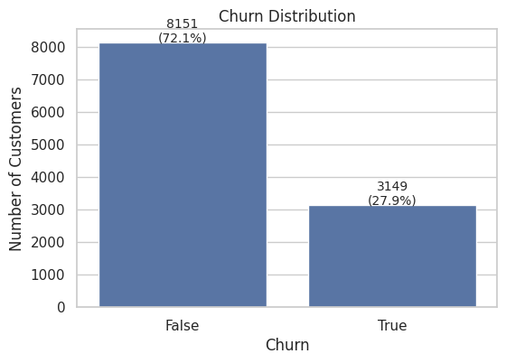

```python
plt.figure(figsize=(6,4))
ax = sns.countplot(x='Churn', data=data)

# Total count for percentage calculation
total = len(data)

# Add labels on top of bars
for p in ax.patches:
    count = int(p.get_height())
    percentage = 100 * count / total
    ax.text(
        p.get_x() + p.get_width() / 2,
        p.get_height() + 5,
        f'{count}\n({percentage:.1f}%)',
        ha='center',
        fontsize=10
    )

plt.title('Churn Distribution')
plt.xlabel('Churn')
plt.ylabel('Number of Customers')
plt.show()
```

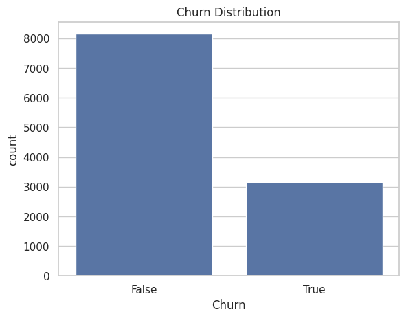

```python
sns.countplot(x='Churn', data=data)
plt.title('Churn Distribution')
plt.show()
```

### 3.2 Univariate Analysis

#### Tenure Distribution

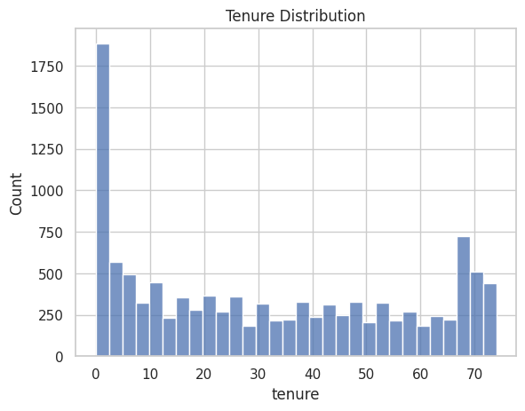

```python
sns.histplot(data['tenure'], bins=30)
plt.title('Tenure Distribution')
plt.show()
```

#### MonthlyCharges Distribution

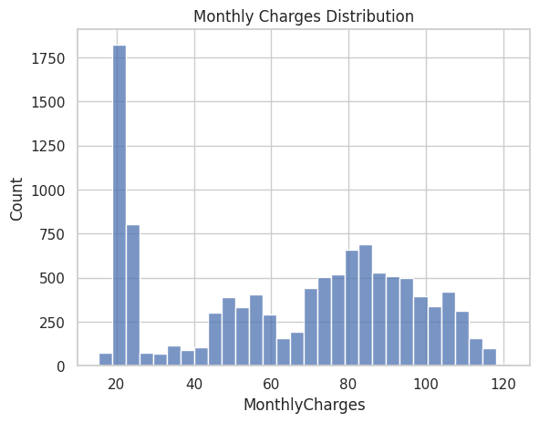

```python
sns.histplot(data['MonthlyCharges'], bins=30)
plt.title('Monthly Charges Distribution')
plt.show()
```

**Observation:**  
Monthly charges show a wide spread, indicating heterogeneous pricing plans although the most famous plans are around 20 dollars where there is a significant peak. Higher charges may increase churn risk if perceived value is low.

### 3.3 Bivariate Analysis

#### Churn by Contract Type

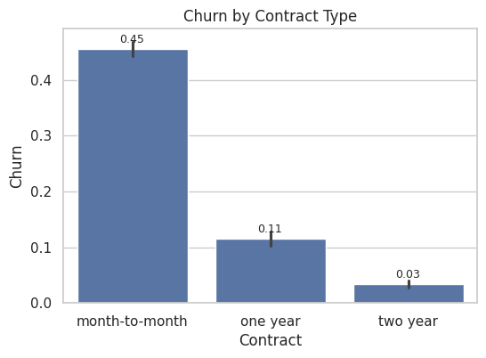

```python
plt.figure(figsize=(6,4))
ax = sns.barplot(x='Contract', y='Churn', data=data)
add_bar_labels(ax)
plt.title('Churn by Contract Type')
plt.show()
```

#### Churn by tenure

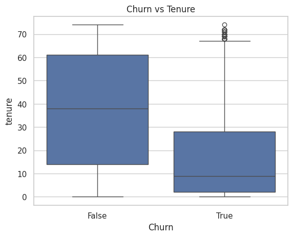

```python
sns.boxplot(x='Churn', y='tenure', data=data)
plt.title('Churn vs Tenure')
plt.show()
```

#### PaymentMethod — Churn Rate

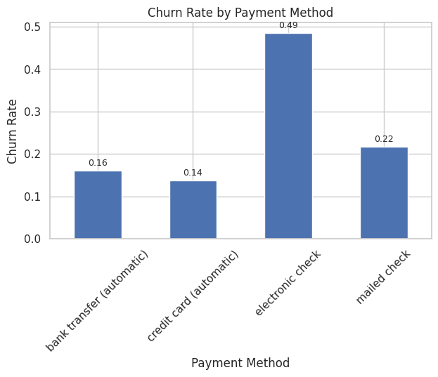

```python
plt.figure(figsize=(7,4))
ax = data.groupby('PaymentMethod')['Churn'].mean().plot(kind='bar')
add_bar_labels(plt.gca())
plt.title("Churn Rate by Payment Method")
plt.ylabel("Churn Rate")
plt.xlabel("Payment Method")
plt.xticks(rotation=45)
plt.show()
```

#### OnlineSecurity — Churn Rate

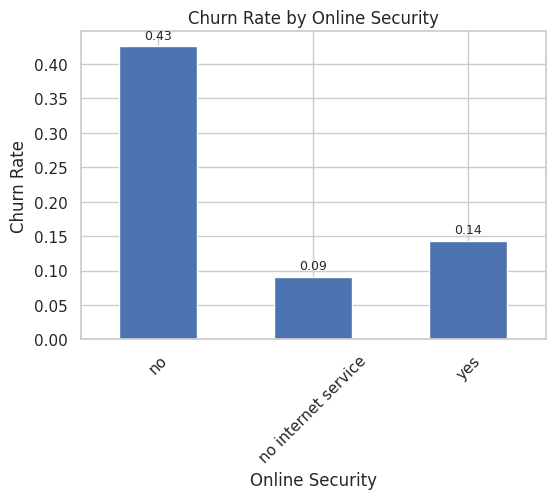

```python
plt.figure(figsize=(6,4))
ax = data.groupby('OnlineSecurity')['Churn'].mean().plot(kind='bar')
add_bar_labels(plt.gca())
plt.title("Churn Rate by Online Security")
plt.ylabel("Churn Rate")
plt.xlabel("Online Security")
plt.xticks(rotation=45)
plt.show()
```

#### TechSupport — Churn Rate

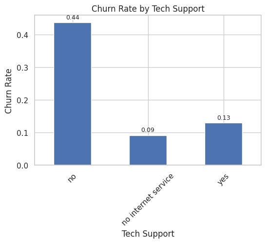

```python
plt.figure(figsize=(6,4))
ax = data.groupby('TechSupport')['Churn'].mean().plot(kind='bar')
add_bar_labels(plt.gca())
plt.title("Churn Rate by Tech Support")
plt.ylabel("Churn Rate")
plt.xlabel("Tech Support")
plt.xticks(rotation=45)
plt.show()
```

#### MonthlyCharges vs Churn

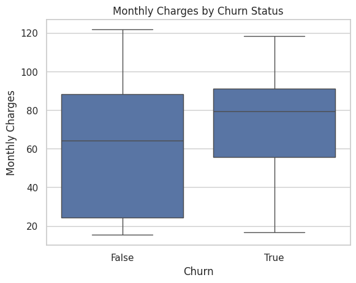

```python
sns.boxplot(x='Churn', y='MonthlyCharges', data=data)
plt.title('Monthly Charges by Churn Status')
plt.xlabel('Churn')
plt.ylabel('Monthly Charges')
plt.show()
```

Customers who churn tend to have higher median monthly charges, indicating price sensitivity plays a role in churn decisions.

### 3.4 Multivariate Analysis

Multivariate analysis helps identify interaction effects where churn is driven by combinations of factors rather than single variables.

#### Churn vs MonthlyCharges vs Tenure

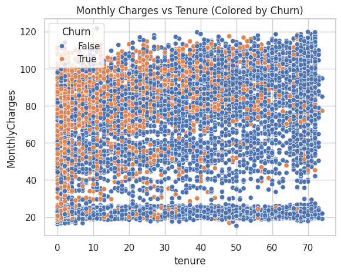

```python
sns.scatterplot(
    x='tenure',
    y='MonthlyCharges',
    hue='Churn',
    data=data
)
plt.title('Monthly Charges vs Tenure (Colored by Churn)')
plt.show()
```

#### Churn vs Contract vs InternetService

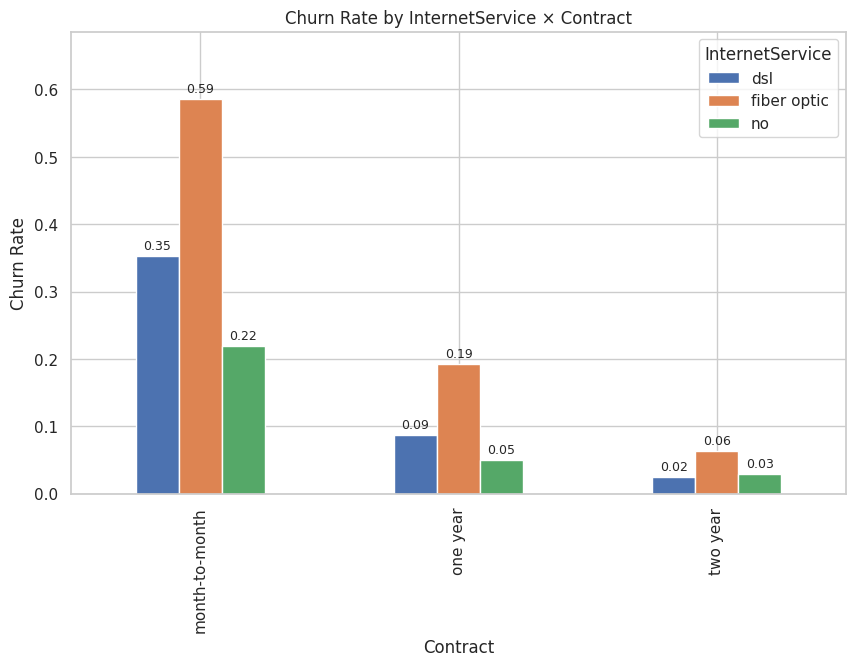

```python
fig, ax = plt.subplots(figsize=(10,6))

churn_matrix = pd.crosstab(
    data['Contract'],
    data['InternetService'],
    values=data['Churn'],
    aggfunc='mean'
)

churn_matrix.plot(kind='bar', ax=ax)

plt.title("Churn Rate by InternetService × Contract")
plt.ylabel("Churn Rate")

# Add value labels on bars
for container in ax.containers:
    for bar in container:
        height = bar.get_height()
        if not np.isnan(height):
            ax.text(
                bar.get_x() + bar.get_width() / 2,
                height + 0.01,
                f"{height:.2f}",
                ha='center',
                fontsize=9
            )

plt.ylim(0, churn_matrix.max().max() + 0.1)
plt.show()
```

#### Churn vs Contract vs Tenure

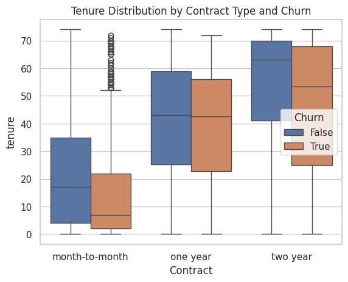

```python
sns.boxplot(x='Contract', y='tenure', hue='Churn', data=data)
plt.title('Tenure Distribution by Contract Type and Churn')
plt.show()
```

Newer Customers tend to go for month to month contracts, and new customers are a significant churn risk

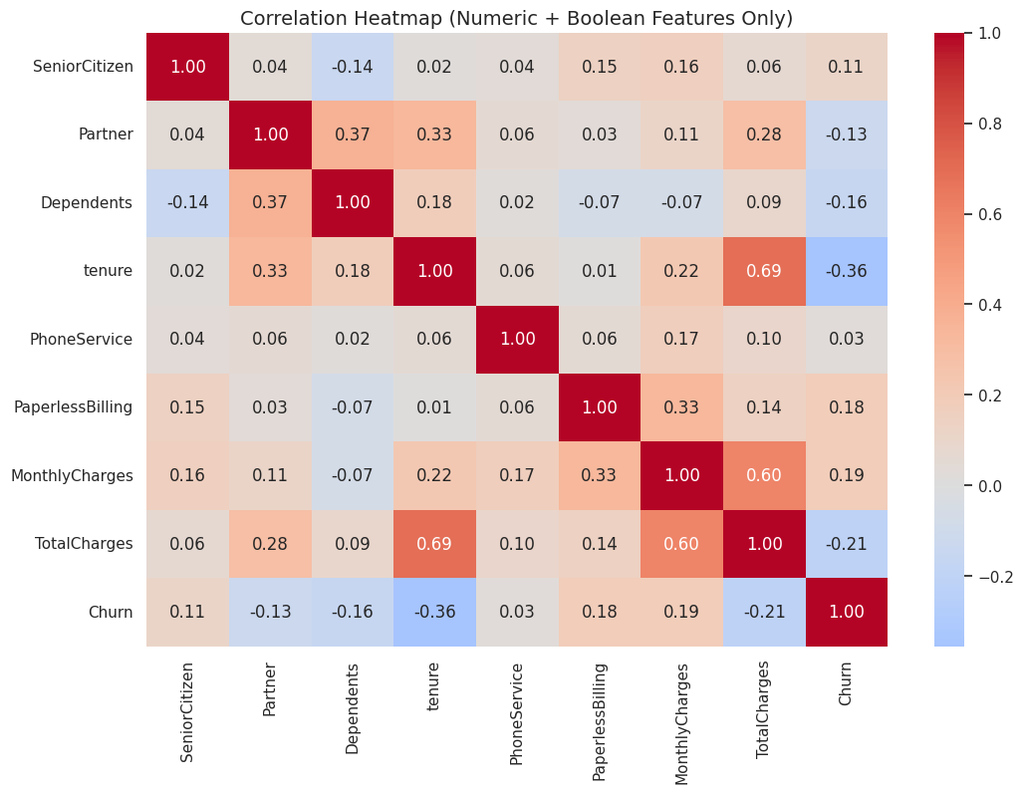

```python
# Make a copy
df_num = data.copy()

# Convert bool → int for correlation
bool_cols = df_num.select_dtypes(include='bool').columns
df_num[bool_cols] = df_num[bool_cols].astype(int)

# Select ONLY numeric columns
df_num = df_num.select_dtypes(include=[np.number])

plt.figure(figsize=(12, 8))
sns.heatmap(
    df_num.corr(),
    annot=True,
    cmap='coolwarm',
    center=0,
    fmt=".2f"
)
plt.title("Correlation Heatmap (Numeric + Boolean Features Only)", fontsize=14)
plt.show()
```

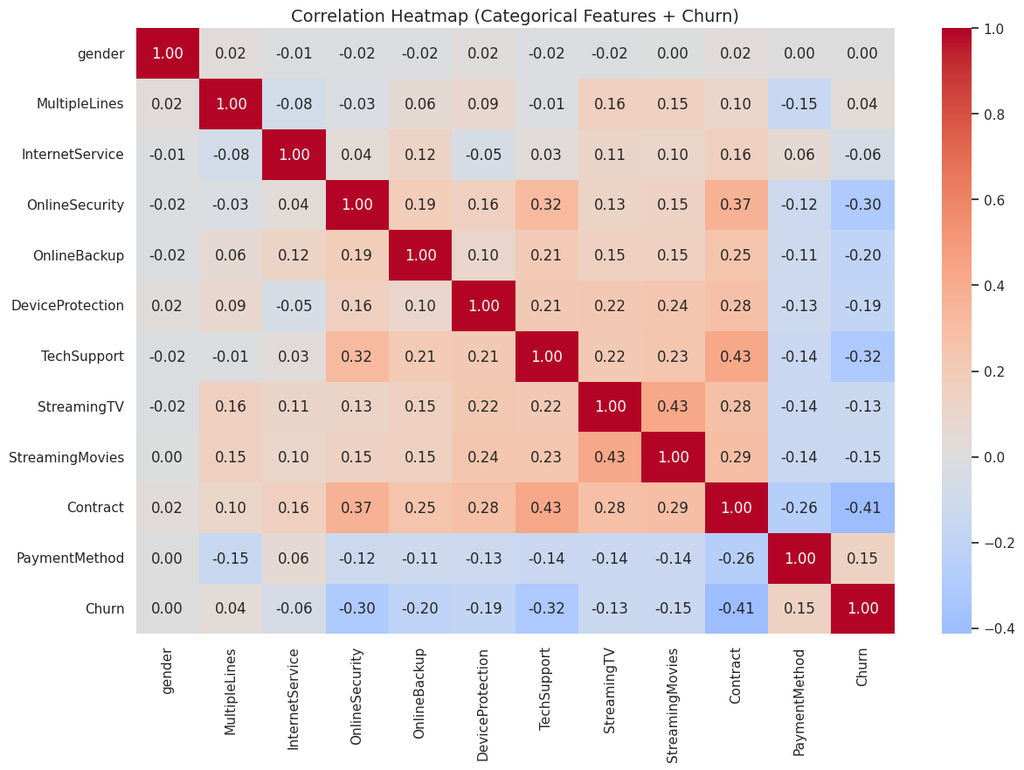

```python
# Select only categorical columns (excluding 'Churn' initially to handle it separately)
df_cat_corr = data.select_dtypes(include='category').copy()

# Convert categorical columns to numerical codes
for col in df_cat_corr.columns:
    df_cat_corr[col] = df_cat_corr[col].astype('category').cat.codes

# Add the 'Churn' column (which is already boolean and can be converted to int)
df_cat_corr['Churn'] = data['Churn'].astype(int)

# Calculate the correlation matrix
correlation_matrix_cat = df_cat_corr.corr(method='pearson')

# Plot the correlation heatmap
plt.figure(figsize=(14, 9))
sns.heatmap(
    correlation_matrix_cat,
    annot=True,
    cmap='coolwarm',
    center=0,
    fmt=".2f"
)
plt.title("Correlation Heatmap (Categorical Features + Churn)", fontsize=14)
plt.show()
```

### 3.6 Key EDA Insights

- Churn is heavily concentrated within the first year of tenure, highlighting onboarding risk.
- Month-to-month contracts exhibit significantly higher churn than long-term contracts.
- Customers with higher monthly charges are more likely to churn, indicating pricing sensitivity.
- Electronic check payment method is associated with higher churn.
- Value-added services such as OnlineSecurity and TechSupport reduce churn probability.
- Fiber optic customers churn more frequently than DSL users.

## 4. Feature Selection & Data Leakage Handling

#### Feature Selection Decision

- Churn is our target variable
- TotalCharges was excluded from modeling due to cumulative billing noise and high correlation with tenure. Only independent customer attributes were used.

#### Data Leakage Prevention

Why TotalCharges was excluded from modeling

TotalCharges is a cumulative billing variable strongly correlated with tenure and partially driven by non-recurring charges. Including it would introduce multicollinearity and potential data leakage. Therefore, it was retained only for exploratory analysis and excluded from predictive modeling.

## 5. Baseline Model – Logistic Regression

### 5.1 Train–Test Split

```python
from sklearn.model_selection import train_test_split

X = data.drop(columns=['Churn','TotalCharges'])
y = data['Churn']

X_train, X_test, y_train, y_test = train_test_split(
    X, y, test_size=0.3, stratify=y, random_state=42
)

X_train = pd.get_dummies(X_train, drop_first=True)
X_test = pd.get_dummies(X_test, drop_first=True)

X_test = X_test.reindex(columns=X_train.columns, fill_value=0)
```

### 5.2 Feature Scaling

```python
from sklearn.preprocessing import StandardScaler

scaler = StandardScaler()
num_cols = ['tenure','MonthlyCharges']

X_train[num_cols] = scaler.fit_transform(X_train[num_cols])
X_test[num_cols] = scaler.transform(X_test[num_cols])
```

Feature scaling was applied to numeric variables to ensure coefficients in logistic regression are comparable and optimization converges efficiently.

### 5.3 Helper Function

```python
from sklearn.metrics import (
    accuracy_score,
    precision_score,
    recall_score,
    f1_score,
    roc_auc_score,
    average_precision_score,
    precision_recall_curve
)

import numpy as np

def evaluate_model(model, X_test, y_test, model_name):
    y_prob = model.predict_proba(X_test)[:, 1]

    precision, recall, thresholds = precision_recall_curve(y_test, y_prob)

    f1_scores = np.nan_to_num(2 * (precision * recall) / (precision + recall))

    best_idx = np.argmax(f1_scores)

    # Guard against extreme thresholds
    best_threshold = thresholds[min(best_idx, len(thresholds)-1)]

    # Prevent degenerate case for trees
    if best_threshold > 0.95:
        best_threshold = 0.5

    y_pred = (y_prob >= best_threshold).astype(int)

    return {
        "Model": model_name,
        "Best Threshold": round(best_threshold, 3),
        "Accuracy": accuracy_score(y_test, y_pred),
        "Precision": precision_score(y_test, y_pred),
        "Recall": recall_score(y_test, y_pred),
        "F1": f1_score(y_test, y_pred),
        "AUC-PR": average_precision_score(y_test, y_prob),
        "ROC-AUC": roc_auc_score(y_test, y_prob)
    }
```

### 5.4 Model Training

```python
from sklearn.linear_model import LogisticRegression
import time


start = time.time()
lr = LogisticRegression(max_iter=1000, class_weight='balanced')
lr.fit(X_train, y_train)
lr_time = round(time.time() - start, 3)

lr_metrics = evaluate_model(lr, X_test, y_test, "Logistic Regression")
lr_metrics["Train_Time_sec"] = lr_time
```

### 5.5 Model Evaluation

#### Metric Rationale

Metric of Choice: AUC-PR and secondary as Recall and ROC-AUC

AUC-PR (Area Under the Precision–Recall Curve) was included as a key evaluation metric. AUC-PR is particularly well-suited for churn prediction problems where class imbalance exists, as it focuses on the model’s ability to correctly identify churners without being influenced by the large number of non-churn customers.

Unlike ROC-AUC, which can appear overly optimistic in imbalanced datasets, AUC-PR provides a more realistic assessment of model performance by jointly evaluating precision and recall across different decision thresholds. This makes it especially valuable for assessing the quality of churn risk ranking and supporting business decisions related to targeted retention campaigns.

Recall was selected as the secondary metric because the business cost of failing to identify a churn-prone customer is higher than the cost of incorrectly targeting a retained customer.

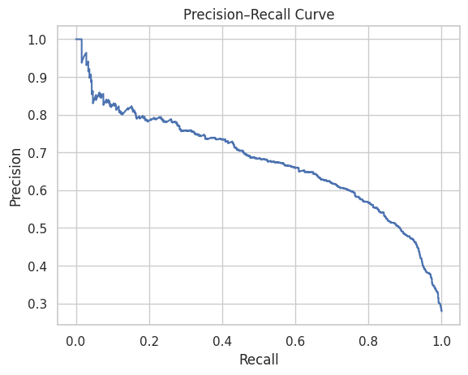

```python
y_prob = lr.predict_proba(X_test)[:, 1]
precision, recall, _ = precision_recall_curve(y_test, y_prob)

plt.plot(recall, precision)
plt.xlabel("Recall")
plt.ylabel("Precision")
plt.title("Precision–Recall Curve")
plt.show()
```

## 6. Advanced Models

We will add these 5 Models:

1. Decision Tree
2. Random Forest
3. Gradient Boosting
4. AdaBoost
5. XGBoost

```python
import time

def train_and_time(model, X_train, y_train):
    start = time.time()
    model.fit(X_train, y_train)
    end = time.time()
    return model, round(end - start, 3)
```

### 6.1 Decision Tree Classifier

```python
from sklearn.tree import DecisionTreeClassifier

dt = DecisionTreeClassifier(
    max_depth=6,
    class_weight='balanced',
    random_state=42
)

start = time.time()
dt.fit(X_train, y_train)
dt_time = round(time.time() - start, 3)

dt_metrics = evaluate_model(dt, X_test, y_test, "Decision Tree")
dt_metrics["Train_Time_sec"] = dt_time
```

### 6.2 Random Forest Classifier

```python
from sklearn.ensemble import RandomForestClassifier

rf = RandomForestClassifier(
    n_estimators=200,
    max_depth=10,
    class_weight='balanced',
    random_state=42,
    n_jobs=-1
)

start = time.time()
rf.fit(X_train, y_train)
rf_time = round(time.time() - start, 3)

rf_metrics = evaluate_model(rf, X_test, y_test, "Random Forest")
rf_metrics["Train_Time_sec"] = rf_time
```

### 6.3 Gradient Boosting Classifier

```python
from sklearn.ensemble import GradientBoostingClassifier

gb = GradientBoostingClassifier(
    n_estimators=200,
    learning_rate=0.05,
    max_depth=3,
    random_state=42
)

start = time.time()
gb.fit(X_train, y_train)
gb_time = round(time.time() - start, 3)

gb_metrics = evaluate_model(gb, X_test, y_test, "Gradient Boosting")
gb_metrics["Train_Time_sec"] = gb_time
```

### 6.4 AdaBoost Classifier

```python
from sklearn.ensemble import AdaBoostClassifier

ab = AdaBoostClassifier(
    n_estimators=200,
    learning_rate=0.05,
    random_state=42
)

start = time.time()
ab.fit(X_train, y_train)
ab_time = round(time.time() - start, 3)

ab_metrics = evaluate_model(ab, X_test, y_test, "AdaBoost")
ab_metrics["Train_Time_sec"] = ab_time
```

### 6.5 XGBoost

```python
from xgboost import XGBClassifier

xgb = XGBClassifier(
    n_estimators=300,
    learning_rate=0.05,
    max_depth=4,
    subsample=0.8,
    colsample_bytree=0.8,
    eval_metric='logloss',
    random_state=42
)

start = time.time()
xgb.fit(X_train, y_train)
xgb_time = round(time.time() - start, 3)

xgb_metrics = evaluate_model(xgb, X_test, y_test, "XGBoost")
xgb_metrics["Train_Time_sec"] = xgb_time
```

### 6.6 Model Comparison Table

```python
results = pd.DataFrame([
    lr_metrics,
    dt_metrics,
    rf_metrics,
    gb_metrics,
    ab_metrics,
    xgb_metrics
])

results_sorted = results.sort_values(
    by="AUC-PR",
    ascending=False
).reset_index(drop=True)

results_sorted.round(4)
```

|  | Model | Best Threshold | Accuracy | Precision | Recall | F1 | AUC-PR | ROC-AUC | Train_Time_sec |
| --- | --- | --- | --- | --- | --- | --- | --- | --- | --- |
| 0 | Gradient Boosting | 0.303 | 0.7841 | 0.5833 | 0.7894 | 0.6709 | 0.6857 | 0.8549 | 3.597 |
| 1 | XGBoost | 0.304 | 0.7764 | 0.5722 | 0.7841 | 0.6616 | 0.6837 | 0.8533 | 0.221 |
| 2 | Random Forest | 0.454 | 0.7755 | 0.5677 | 0.8159 | 0.6696 | 0.6776 | 0.8528 | 2.451 |
| 3 | Logistic Regression | 0.582 | 0.7894 | 0.5962 | 0.7577 | 0.6673 | 0.6770 | 0.8527 | 0.202 |
| 4 | AdaBoost | 0.402 | 0.7864 | 0.5932 | 0.7439 | 0.6601 | 0.6478 | 0.8441 | 1.842 |
| 5 | Decision Tree | 0.553 | 0.7705 | 0.5643 | 0.7757 | 0.6533 | 0.6309 | 0.8396 | 0.113 |

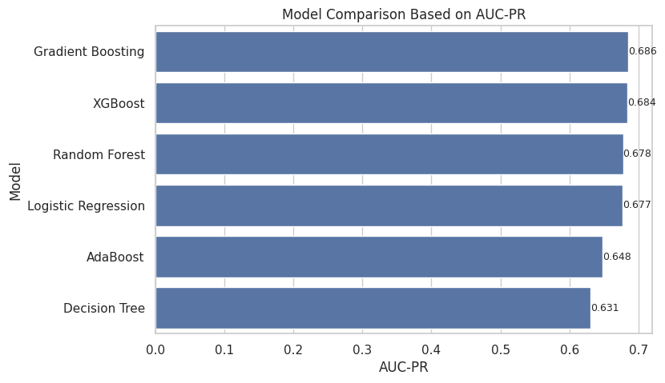

```python
plt.figure(figsize=(8,5))
ax = sns.barplot(x="AUC-PR", y="Model", data=results_sorted)
for p in ax.patches:
    ax.annotate(f"{p.get_width():.3f}",
                (p.get_width(), p.get_y() + p.get_height()/2),
                va='center', ha='left', fontsize=9)

plt.title("Model Comparison Based on AUC-PR")
plt.xlabel("AUC-PR")
plt.ylabel("Model")
plt.show()
```

## 7.Model Tuning

### Why hyperparameter tuning is required

Initial model results indicate that while several models demonstrate reasonable predictive performance, their default or manually chosen hyperparameters may not be optimal for maximizing the primary evaluation metric (AUC-PR). Since churn prediction involves class imbalance and asymmetric business costs, improving the ranking and identification of churners is more valuable than marginal gains in overall accuracy. Hyperparameter tuning is therefore applied to models that are both expressive enough to capture non-linear relationships and stable enough to benefit from controlled optimization.

### Models Selected for Hyperparameter Tuning

#### 1.Random Forest

#### 2.Gradient Boosting

#### 3. XGBoost

### How the Tuning Strategy Was Decided

#### Metric-driven tuning approach

Hyperparameter tuning was explicitly aligned with the metric of choice: AUC-PR. Unlike accuracy or ROC-AUC, AUC-PR directly reflects the model’s ability to correctly rank churners higher than non-churners in an imbalanced dataset.

Therefore:

Scoring metric: average_precision

Objective: Improve churner ranking quality rather than raw classification accuracy

#### Search strategy

GridSearchCV (or RandomizedSearchCV for larger parameter spaces) was used to systematically explore combinations of hyperparameters that affect:

Model complexity

Generalization ability

Recall–precision balance

Cross-validation ensured that improvements were robust and not driven by a single data split.

#### 7.1 Tuning Utility Function

```python
from sklearn.model_selection import RandomizedSearchCV, GridSearchCV, StratifiedKFold

def tune_model(model, param_space, X_train, y_train, model_name,
               strategy="random", n_iter=80, cv=5):

    print(f"\n🔧 Tuning {model_name}...")

    # Automatically handle class imbalance where applicable
    if 'class_weight' in model.get_params() and model_name not in ["Gradient Boosting", "XGBoost"]:
        model.set_params(class_weight="balanced")

    cv_strategy = StratifiedKFold(n_splits=cv, shuffle=True, random_state=42)

    if strategy == "random":
        search = RandomizedSearchCV(
            model, param_space, n_iter=n_iter,
            scoring="average_precision", cv=cv_strategy,
            n_jobs=-1, verbose=1, random_state=42
        )

    elif strategy == "grid":
        search = GridSearchCV(
            model, param_space,
            scoring="average_precision", cv=cv_strategy,
            n_jobs=-1, verbose=1
        )
    else:
        raise ValueError("strategy must be 'random' or 'grid'")

    search.fit(X_train, y_train)

    print(f"Best Parameters for {model_name}:")
    for k, v in search.best_params_.items():
        print(f"   {k}: {v}")

    print(f"Best CV AUC-PR: {search.best_score_:.4f}")

    return search.best_estimator_
```

#### 7.2 Random forest

```python
rf_param_space = {
    "n_estimators": [300, 500, 800],
    "max_depth": [10, 20, 30, None],
    "min_samples_split": [2, 5, 10, 20],
    "min_samples_leaf": [1, 2, 4, 10],
    "max_features": ["sqrt", "log2", 0.5],
    "max_samples": [0.7, 0.8, 0.9],
    "criterion": ["gini", "entropy"]
}

start = time.time()
rf_tuned = tune_model(
    RandomForestClassifier(random_state=42),
    rf_param_space, X_train, y_train,
    "Random Forest", strategy="random"
)
rf_time = round(time.time() - start, 3)

rf_tuned_metrics = evaluate_model(rf_tuned, X_test, y_test, "Random Forest (Tuned)")
rf_tuned_metrics["Train_Time_sec"] = rf_time
```

```
🔧 Tuning Random Forest...
Fitting 5 folds for each of 80 candidates, totalling 400 fits
Best Parameters for Random Forest:
   n_estimators: 500
   min_samples_split: 2
   min_samples_leaf: 10
   max_samples: 0.9
   max_features: sqrt
   max_depth: 30
   criterion: entropy
Best CV AUC-PR: 0.6784
```

```python
tuned_model_results = []
tuned_model_results.append(rf_tuned_metrics)
```

#### 7.3 gradient boosting

```python
gb = GradientBoostingClassifier(
    random_state=42,
    validation_fraction=0.1,
    n_iter_no_change=15,
    tol=1e-4
)
```

```python
gb_param_space = {
    "n_estimators": [200, 400, 600, 800],
    "learning_rate": [0.005, 0.01, 0.03, 0.05, 0.1],
    "max_depth": [2, 3, 4, 5],
    "min_samples_leaf": [1, 3, 5, 10],
    "min_samples_split": [2, 5, 10],
    "subsample": [0.6, 0.75, 0.9, 1.0],
    "max_features": ["sqrt", "log2", None]
}


start = time.time()
gb_tuned = tune_model(
    gb,
    gb_param_space,
    X_train,
    y_train,
    "Gradient Boosting",
    strategy="random",
    n_iter=120,      # increase search coverage
    cv=5
)
gb_time = round(time.time() - start, 3)

gb_tuned_metrics = evaluate_model(gb_tuned, X_test, y_test, "Gradient Boosting (Tuned)")
gb_tuned_metrics["Train_Time_sec"] = gb_time
```

```
🔧 Tuning Gradient Boosting...
Fitting 5 folds for each of 120 candidates, totalling 600 fits
Best Parameters for Gradient Boosting:
   subsample: 0.75
   n_estimators: 600
   min_samples_split: 2
   min_samples_leaf: 10
   max_features: None
   max_depth: 3
   learning_rate: 0.03
Best CV AUC-PR: 0.6812
```

```python
tuned_model_results.append(gb_tuned_metrics)
```

#### 7.4 xgboost

```python
from scipy.stats import uniform, randint

xgb_param_space = {
    "n_estimators": randint(300, 1500),
    "learning_rate": uniform(0.005, 0.15),
    "max_depth": randint(2, 10),
    "min_child_weight": randint(1, 12),
    "subsample": uniform(0.6, 0.4),
    "colsample_bytree": uniform(0.6, 0.4),
    "colsample_bylevel": uniform(0.6, 0.4),
    "gamma": uniform(0, 8),
    "reg_alpha": uniform(0, 3),
    "reg_lambda": uniform(0.5, 4),
    "max_delta_step": randint(0, 10)
}


start = time.time()

xgb_tuned = tune_model(
    XGBClassifier(
        eval_metric="logloss",
        tree_method="hist",
        random_state=42
    ),
    xgb_param_space,
    X_train,
    y_train,
    "XGBoost",
    strategy="random",
    n_iter=200,   # much deeper exploration
    cv=5
)

xgb_tuned.set_params(
    early_stopping_rounds=20,
    eval_metric="aucpr"
)

xgb_tuned.fit(
    X_train, y_train,
    eval_set=[(X_test, y_test)],
    verbose=False
)


xgb_time = round(time.time() - start, 3)


xgb_tuned_metrics = evaluate_model(xgb_tuned, X_test, y_test, "XGBoost (Tuned)")
xgb_tuned_metrics["Train_Time_sec"] = xgb_time
```

```
🔧 Tuning XGBoost...
Fitting 5 folds for each of 200 candidates, totalling 1000 fits
Best Parameters for XGBoost:
   colsample_bylevel: 0.749816047538945
   colsample_bytree: 0.9802857225639665
   gamma: 5.855951534491241
   learning_rate: 0.0947987726295555
   max_delta_step: 6
   max_depth: 3
   min_child_weight: 3
   n_estimators: 630
   reg_alpha: 1.3777466758976016
   reg_lambda: 1.8348344445560874
   subsample: 0.6571467271687763
Best CV AUC-PR: 0.6838
```

```python
tuned_model_results.append(xgb_tuned_metrics)
```

#### 7.5 Final Tuned Comparison

```python
tuned_results = pd.DataFrame([rf_tuned_metrics, gb_tuned_metrics, xgb_tuned_metrics])
tuned_results = tuned_results.sort_values("AUC-PR", ascending=False).reset_index(drop=True)

tuned_results.round(4)
```

|  | Model | Best Threshold | Accuracy | Precision | Recall | F1 | AUC-PR | ROC-AUC | Train_Time_sec |
| --- | --- | --- | --- | --- | --- | --- | --- | --- | --- |
| 0 | XGBoost (Tuned) | 0.358 | 0.7994 | 0.6163 | 0.7429 | 0.6737 | 0.6863 | 0.8559 | 349.059 |
| 1 | Gradient Boosting (Tuned) | 0.314 | 0.7879 | 0.5911 | 0.7757 | 0.6709 | 0.6847 | 0.8550 | 564.846 |
| 2 | Random Forest (Tuned) | 0.537 | 0.7956 | 0.6103 | 0.7376 | 0.6679 | 0.6815 | 0.8542 | 844.213 |

```python
tuned_results = pd.DataFrame([
    rf_tuned_metrics,
    gb_tuned_metrics,
    xgb_tuned_metrics
])

tuned_results = tuned_results.sort_values("AUC-PR", ascending=False).reset_index(drop=True)
tuned_results.round(4)
```

|  | Model | Best Threshold | Accuracy | Precision | Recall | F1 | AUC-PR | ROC-AUC | Train_Time_sec |
| --- | --- | --- | --- | --- | --- | --- | --- | --- | --- |
| 0 | XGBoost (Tuned) | 0.358 | 0.7994 | 0.6163 | 0.7429 | 0.6737 | 0.6863 | 0.8559 | 349.059 |
| 1 | Gradient Boosting (Tuned) | 0.314 | 0.7879 | 0.5911 | 0.7757 | 0.6709 | 0.6847 | 0.8550 | 564.846 |
| 2 | Random Forest (Tuned) | 0.537 | 0.7956 | 0.6103 | 0.7376 | 0.6679 | 0.6815 | 0.8542 | 844.213 |

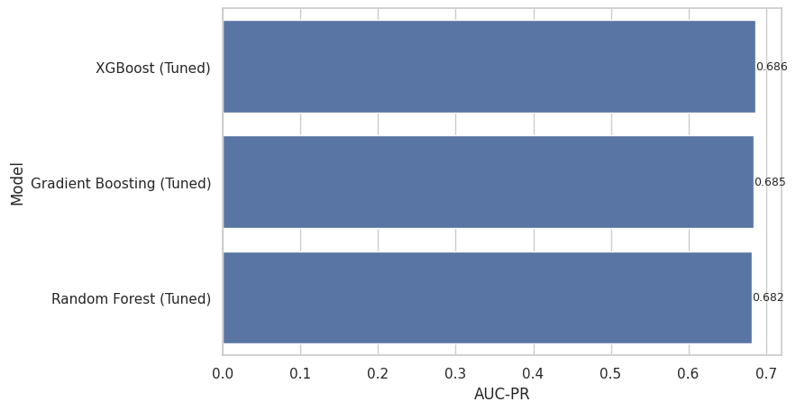

```python
plt.figure(figsize=(8,5))
ax = sns.barplot(x="AUC-PR", y="Model", data=tuned_results)
for p in ax.patches:
    ax.annotate(f"{p.get_width():.3f}",
                (p.get_width(), p.get_y() + p.get_height()/2),
                va='center', ha='left', fontsize=9)
```

#### 7.6 final comparison table with improvement

```python
# Build baseline and tuned tables
baseline_models = pd.DataFrame([rf_metrics, gb_metrics, xgb_metrics])
tuned_models = pd.DataFrame([rf_tuned_metrics, gb_tuned_metrics, xgb_tuned_metrics])

# Create consistent merge keys
baseline_models['Model_Key'] = baseline_models['Model'].str.lower().str.strip()
tuned_models['Model_Key'] = tuned_models['Model'].str.lower().str.replace(' (tuned)', '', regex=False).str.strip()

# Merge
comparison = pd.merge(
    baseline_models,
    tuned_models,
    on='Model_Key',
    suffixes=('_Untuned', '_Tuned')
)

# Compute improvements
# Compute improvements
for metric in ['AUC-PR', 'Recall', 'ROC-AUC']:
    comparison[f'{metric}_Improvement'] = comparison[f'{metric}_Tuned'] - comparison[f'{metric}_Untuned']
    comparison[f'{metric}_Improvement_%'] = (
        comparison[f'{metric}_Improvement'] / comparison[f'{metric}_Untuned'] * 100
    )


# Final executive table
final_comparison_table = comparison[
    [
        'Model_Untuned',

        'AUC-PR_Untuned', 'AUC-PR_Tuned', 'AUC-PR_Improvement_%',
        'Recall_Untuned', 'Recall_Tuned', 'Recall_Improvement_%',
        'ROC-AUC_Untuned', 'ROC-AUC_Tuned',
        'ROC-AUC_Improvement_%'
    ]
].round(3)

final_comparison_table
```

|  | Model_Untuned | AUC-PR_Untuned | AUC-PR_Tuned | AUC-PR_Improvement_% | Recall_Untuned | Recall_Tuned | Recall_Improvement_% | ROC-AUC_Untuned | ROC-AUC_Tuned | ROC-AUC_Improvement_% |
| --- | --- | --- | --- | --- | --- | --- | --- | --- | --- | --- |
| 0 | Random Forest | 0.678 | 0.682 | 0.571 | 0.816 | 0.738 | -9.598 | 0.853 | 0.854 | 0.169 |
| 1 | Gradient Boosting | 0.686 | 0.685 | -0.140 | 0.789 | 0.776 | -1.743 | 0.855 | 0.855 | 0.012 |
| 2 | XGBoost | 0.684 | 0.686 | 0.391 | 0.784 | 0.743 | -5.263 | 0.853 | 0.856 | 0.298 |

#### 7.7 Create Clean Untuned vs Tuned Time Comparison Table

```python
time_comparison = pd.DataFrame({
    "Model": ["Random Forest", "Gradient Boosting", "XGBoost"],

    "Untuned_Time_sec": [
        rf_metrics["Train_Time_sec"],
        gb_metrics["Train_Time_sec"],
        xgb_metrics["Train_Time_sec"]
    ],

    "Tuned_Time_sec": [
        rf_tuned_metrics["Train_Time_sec"],
        gb_tuned_metrics["Train_Time_sec"],
        xgb_tuned_metrics["Train_Time_sec"]
    ],

    "Untuned_AUC_PR": [
        rf_metrics["AUC-PR"],
        gb_metrics["AUC-PR"],
        xgb_metrics["AUC-PR"]
    ],

    "Tuned_AUC_PR": [
        rf_tuned_metrics["AUC-PR"],
        gb_tuned_metrics["AUC-PR"],
        xgb_tuned_metrics["AUC-PR"]
    ]
})

# Compute improvements
time_comparison["Time_Increase_%"] = (
    (time_comparison["Tuned_Time_sec"] - time_comparison["Untuned_Time_sec"]) /
     time_comparison["Untuned_Time_sec"] * 100
)

time_comparison["AUC_PR_Improvement"] = (
    time_comparison["Tuned_AUC_PR"] - time_comparison["Untuned_AUC_PR"]
)

time_comparison["AUC_PR_Improvement_%"] = (
    time_comparison["AUC_PR_Improvement"] /
    time_comparison["Untuned_AUC_PR"] * 100
)

time_comparison.round(3)
```

|  | Model | Untuned_Time_sec | Tuned_Time_sec | Untuned_AUC_PR | Tuned_AUC_PR | Time_Increase_% | AUC_PR_Improvement | AUC_PR_Improvement_% |
| --- | --- | --- | --- | --- | --- | --- | --- | --- |
| 0 | Random Forest | 2.451 | 844.213 | 0.678 | 0.682 | 34343.615 | 0.004 | 0.571 |
| 1 | Gradient Boosting | 3.597 | 564.846 | 0.686 | 0.685 | 15603.253 | -0.001 | -0.140 |
| 2 | XGBoost | 0.221 | 349.059 | 0.684 | 0.686 | 157845.249 | 0.003 | 0.391 |

```python
# Head-to-head comparison: Untuned GB vs Tuned XGBoost

gb_baseline = gb_metrics.copy()
xgb_final = xgb_tuned_metrics.copy()

comparison_head2head = pd.DataFrame([
    gb_baseline,
    xgb_final
])

comparison_head2head = comparison_head2head[
    ["Model", "Train_Time_sec", "AUC-PR", "Recall", "ROC-AUC", "Precision", "Accuracy"]
].round(3)

comparison_head2head
```

|  | Model | Train_Time_sec | AUC-PR | Recall | ROC-AUC | Precision | Accuracy |
| --- | --- | --- | --- | --- | --- | --- | --- |
| 0 | Gradient Boosting | 3.597 | 0.686 | 0.789 | 0.855 | 0.583 | 0.784 |
| 1 | XGBoost (Tuned) | 349.059 | 0.686 | 0.743 | 0.856 | 0.616 | 0.799 |